# PMS Study

Mitchel Kappen & Sofie Raeymakers

15. September 2021

## PMS Study

This is the data processing html for the PMS study

```r
#### IMPORT DATA & INSPECTION #### -------------------------------------------------------------
knitr::opts_knit$set(root.dir = dirname(rstudioapi::getActiveDocumentContext()$path))# Set working directory to current directory
# setwd("C:\Users\ASUSTeK\OneDrive\2021-2022\internship\projects")
data <- read.csv("Data/allPMSdata.csv", header=TRUE)
# data <- read.table("Data/allPMSdata.csv",sep="\t", header=TRUE)


# from wide to long
#check if subject column is a facctor
#str(data)
#head(data)
# data <-as.numeric(data)
data$Subject <- factor(data$ID)
#typeof(data$Subject)


#we make a new variable that has value 1 for the first TestMoment and 2 for the second TestMoment
#These moments were counterbalanced
#when the order was B-A and the moment is B, this means it is the first test moment
#and vice versa for A-B and moment A.

# TestMoment 1 == Follicular phase
# TestMoment 2 == Luteal phase
data$TestMoment[data$Order == "A-B" & data$Moment == "A"] = 1
data$TestMoment[data$Order == "B-A" & data$Moment == "A"] = 2
data$TestMoment[data$Order == "A-B" & data$Moment == "B"] = 2
data$TestMoment[data$Order == "B-A" & data$Moment == "B"] = 1
#check if there are still values missing (NA)
#sum(is.na(data$TestMoment))

# new variable PMSSCORE NEW iedereen pms 0 ook 0 iedereen die 1 OF 2 heeft wordt 1,
data$PMSScoreNew[data$PMSScore==0] = 'noPMS'
data$PMSScoreNew[data$PMSScore==1] = 'PMS'
data$PMSScoreNew[data$PMSScore==2] = 'PMS'
#sum(is.na(data$PMSScoreNew))


# Check whether R recognizes the variable types correctly
#we make factors of the independable variables

data$PMSScore <- factor(data$PMSScore)
data$PMSScoreNew <- factor(data$PMSScoreNew)

data$Moment <- factor(data$TestMoment) # This removes "A and B", A == 1, B == 2 now

# Exclude data?
dataBig = data # Saved all the data here
data = data[, -which(names(data) == "X" | names(data) == "Stimulus" | names(data) == "Valence" | names(data) == "Arousal" | names(data) == "rt")]
data = distinct(data)

# exclude everyone on the pill/copper spiral/other: only those with Natural Contraception are left included
data<-subset(data, Contraception!="Pill" & Contraception!="other" & Contraception!="Cop. Coil" & Contraception!="Hor.Coil")

data <- subset(data, BSRI != 0) #remove 0's from BSRI

# Define the formula for the model & check which model fits the data best
formulas = c('PSS ~ PMSScoreNew*TestMoment', 'BSRI ~PMSScoreNew*TestMoment') # important! after the ~should be the same every time

plotTitles = c('PSS', 'BSRI')

data_temp <- data #to get back tof

# Define the formula for the model & check which model fits the data best
for (i in 2){

  #Formula <- BSRI~PMSScoreNew*TestMoment + (1|Subject)
  Formula <- paste0(formulas[i], ' + (1|Subject)')
  d0.1 <- lmer(Formula,data=data)
  d0.2 <- glmer(Formula,data=data, family = gaussian(link = "inverse"),glmerControl(optimizer= "bobyqa", optCtrl = list(maxfun = 100000)),nAGQ=nAGQ)
  d0.3 <- glmer(Formula,data=data, family = gaussian(link = "log"),glmerControl(optimizer= "bobyqa", optCtrl = list(maxfun = 100000)),nAGQ=nAGQ)

  d0.4 <- glmer(Formula,data=data, family = Gamma(link = "identity"),glmerControl(optimizer= "bobyqa", optCtrl = list(maxfun = 100000)),nAGQ=nAGQ)
  d0.5 <- glmer(Formula,data=data, family = Gamma(link = "inverse"),glmerControl(optimizer= "bobyqa", optCtrl = list(maxfun = 100000)),nAGQ=nAGQ)
  d0.6 <- glmer(Formula,data=data, family = Gamma(link = "log"),glmerControl(optimizer= "bobyqa", optCtrl = list(maxfun = 100000)),nAGQ=nAGQ)

  d0.7 <- glmer(Formula,data=data, family = inverse.gaussian(link = "identity"),glmerControl(optimizer= "bobyqa", optCtrl = list(maxfun = 100000)),nAGQ=nAGQ)
  d0.8 <- glmer(Formula,data=data, family = inverse.gaussian(link = "inverse"),glmerControl(optimizer= "bobyqa", optCtrl = list(maxfun = 100000)),nAGQ=nAGQ)
  d0.9 <- glmer(Formula,data=data, family = inverse.gaussian(link = "log"),glmerControl(optimizer= "bobyqa", optCtrl = list(maxfun = 100000)),nAGQ=nAGQ)

  modelNames = c(d0.1,d0.2,d0.3,d0.4,d0.5,d0.6,d0.7,d0.8,d0.9)

  # Remove the models that produced errors in the line below, the one with the lowest value is the best fitting model
  tabel <- cbind(AIC(d0.1), AIC(d0.2), AIC(d0.3), AIC(d0.4), AIC(d0.5), AIC(d0.6), AIC(d0.7), AIC(d0.8), AIC(d0.9))
  #show table in html
  kable (tabel, caption = "table showing the different AIC")
  chosenModel = modelNames[which(tabel == min(tabel))]

  cat('## ')# header
  # Anova_table <- Anova(chosenModel[1])
  # Anova_table %>%
  #   kable ()%s>%
  #   kable_styling(bootstrap_options = c("striped"))
  Anova(chosenModel[[1]])#make sure it prints anova output in html file
  cat("\n")
#   Analysis of Deviance Table (Type II Wald chisquare tests)
#
# Response: PSS
#                          Chisq Df Pr(>Chisq)
# PMSScoreNew            10.8504  1  0.0009877 ***
# TestMoment              0.4827  1  0.4872097
# PMSScoreNew:TestMoment  0.0272  1  0.8689949
# ---
# Signif. codes:  0 ‘***’ 0.001 ‘**’ 0.01 ‘*’ 0.05 ‘.’ 0.1 ‘ ’ 1
  cat(' ## ')#header
  emmeans(chosenModel[[1]], pairwise ~ PMSScoreNew*TestMoment , adjust ="fdr", type="response")
  cat("\n")
#  PMSScoreNew TestMoment emmean    SE  df asymp.LCL asymp.UCL
#  noPMS                1   29.4 0.289 Inf      28.8      30.0
#  PMS                  1   30.5 0.306 Inf      29.9      31.1
#  noPMS                2   29.2 0.300 Inf      28.6      29.8
#  PMS                  2   30.4 0.327 Inf      29.8      31.1
#
# Confidence level used: 0.95
#
# $contrasts
#  contrast          estimate    SE  df z.ratio p.value
#  noPMS 1 - PMS 1     -1.142 0.421 Inf  -2.713  0.0133 *
#  noPMS 1 - noPMS 2    0.204 0.325 Inf   0.626  0.6376
#  noPMS 1 - PMS 2     -1.018 0.436 Inf  -2.334  0.0294 *
#  PMS 1 - noPMS 2      1.345 0.429 Inf   3.137  0.0102 *
#  PMS 1 - PMS 2        0.124 0.360 Inf   0.344  0.7311
#  noPMS 2 - PMS 2     -1.222 0.444 Inf  -2.751  0.0133 *
#
# P value adjustment: fdr method for 6 tests

    # Plotting

    # abline(lm(formulas[i], data=data), lwd=4, lty=2, col = "red")
    dpi=600    #pixels per square inch

  # jpeg(paste0(plotPrefix, "Figure", "_", plotTitles[i], ".jpeg"), width=8*dpi, height=4*dpi, res=dpi)
    par(mfcol = c(1, 1))
    plotPSS_1 <- pirateplot(
      formula = formulas[i],
      data = data,
      theme = 1,
      pal = "info",
      main = plotTitles[i],
      bean.f.o = .6, # Bean fill
      point.o = .3,  # Points
      inf.f.o = .7,  # Inference fill
      inf.b.o = .8,  # Inference border
      avg.line.o = 1,  # Average line
      # bar.f.o = .5, # Bar
      inf.f.col = "white",  # Inf fill col
      inf.b.col = "black",  # Inf border col
      avg.line.col = "black",  # avg line col
      bar.f.col = gray(.8),  # bar filling color
      point.pch = 21,
      point.bg = "white",
      point.col = "black",
      point.cex = .7,

      xlab = "",
    )

    # Insert visual indicators of significance
  x <- 1:2  # capture x coordinates of bars
  y <- 35  # create the y coordinate of the line
  offset <- 0.2  # set an offset for tick lengths
  lines(c(1.2,1.8),c(y, y))  # draw first horizontal line
  lines(c(1.2,1.2),c(y, y-offset))  # draw ticks
  lines(c(1.8,1.8),c(y, y-offset))
  text(x[1]+((x[2]-x[1])/2),y+offset,"0.01*")  # draw asterics

  cat("\n")
}
```

##

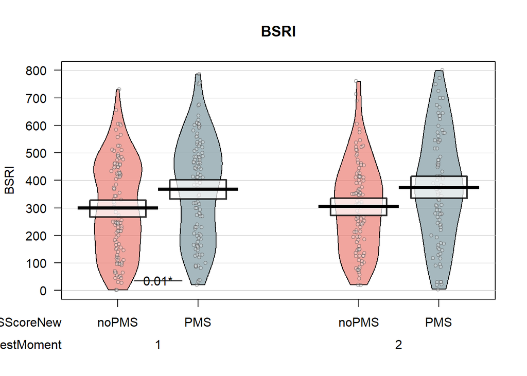

## Plots

Here are some plots:

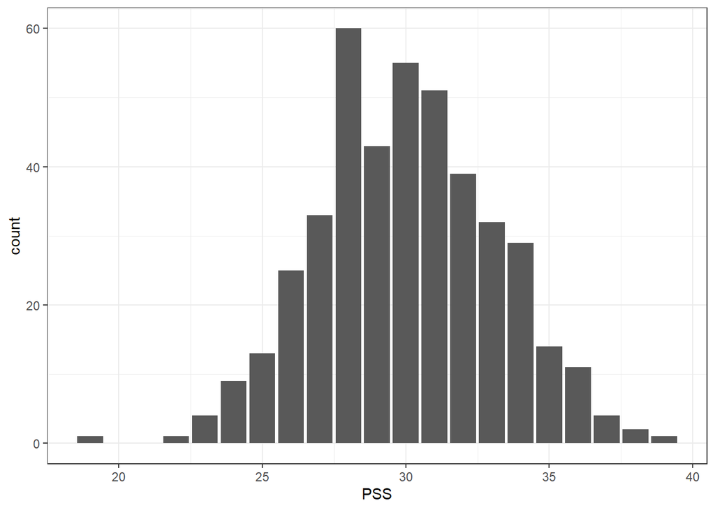

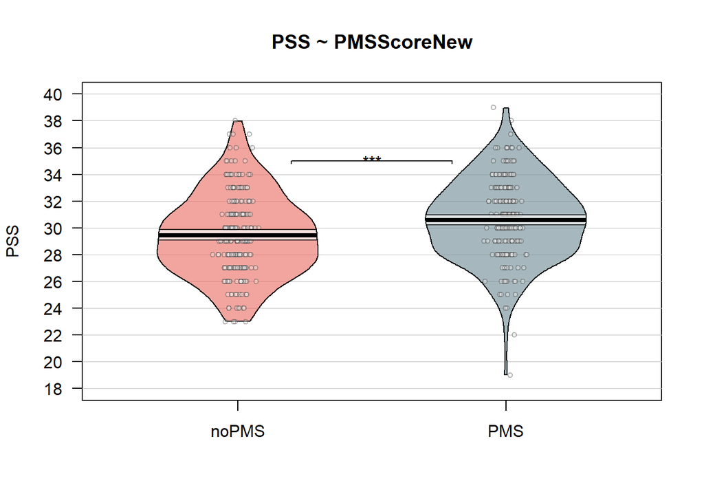

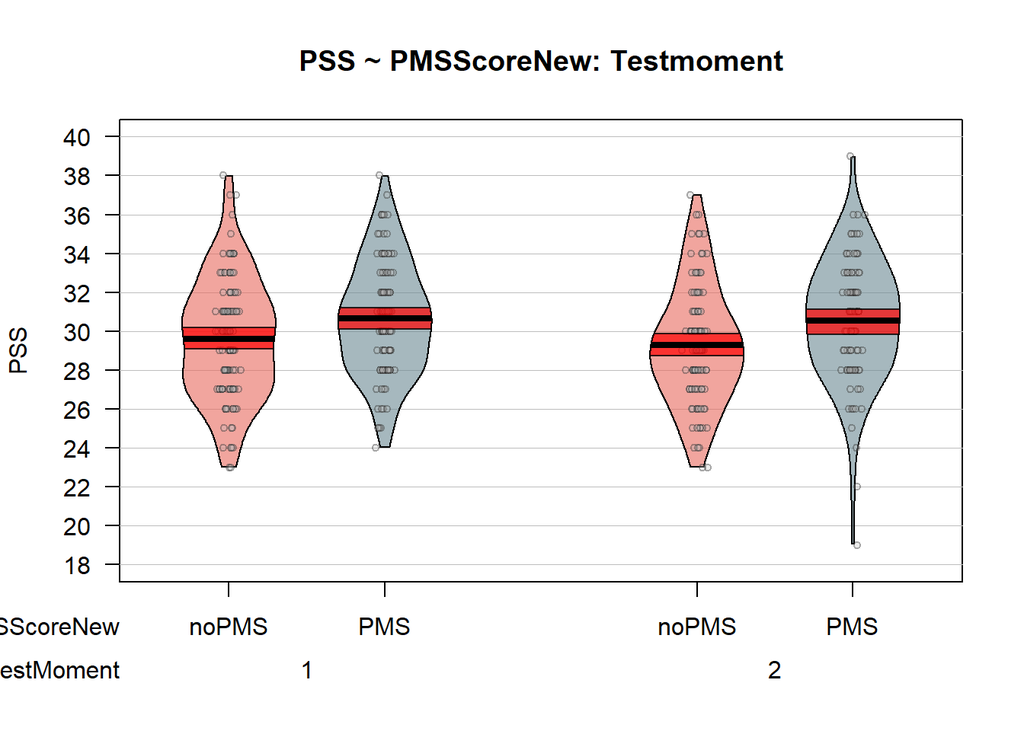

```
##    Min. 1st Qu.  Median    Mean 3rd Qu.    Max.
##      19      28      30      30      32      39
```

##we have more participants with low PMS score

There are 221 people with low PMS score and 206 people with high PMS score

The mean age is 33.3

## Outliers

39, 19 39, 19

## Q

28, 32

## IQR UP

38

## IQR LOW

22

The End!

Hyptothesen en onderzoeksvragen:

TO DO Woensdag:

re-check Anova en emmeans

PMS vs noPMS op het gebied van: - PSS - BSRI

++ Interactie testmoment

PMS vs noPMS voor: - DASS_alle subschalen – Hoeft niet x testmoment

=> automatiseer dit: via for loop

——- Voor de stimuli ———– Eerste stap: - Bekijken Valence en arousal tussen de groepen en testmomenten, over alle stimuli als een geheel

Next: - Per stimulus gemiddelden plotten – Om erachter te komen of er coherent geantwoord wordt – Om te zien of ze niet te veel van elkaar afwijken — waarchuwing; ze gaan veel van elkaar afwijken.

Stimuli onderverdelen in negatief, positief en neutral, om daar een subdivisie analyse op te maken *noot: iaos images, ze zijn getagged (zoek op om ze te kunnen onderverdelen). 22, gematched (dus bv naald in arm vs naald in been)

—————- Overig: Normgroepen opzoeken voor PSS bij (jonge) vrouwen https://www.cambridge.org/core/journals/spanish-journal-of-psychology/article/abs/perceived-stress-scale-pss-normative-data-and-factor-structure-for-a-largescale-sample-in-mexico/752B62D15A932A2D148D04376E949F67

https://bmcpsychiatry.biomedcentral.com/articles/10.1186/s12888-016-0875-9/tables/6